# ERD data exploration

Heather

11/21/2016

Load the libraries, define global objects

[output not shown]

```
                                  Parent folder: /ncdf/
```

1(4.) File: aviso_delayed_time_madt_h_DATE.nc (get attributes and plot)

```
## File /Volumes/SeaGate/ERD_DOM/ncdf/aviso_delayed_time_madt_h_1993-01-01.nc (NC_FORMAT_CLASSIC):
##
##      1 variables (excluding dimension variables):
##         double adt[longitude,latitude,time]
##             _FillValue: -214748.3647
##             colorBarMaximum: 2
##             colorBarMinimum: -2
##             grid_mapping: crs
##             ioos_category: Bathymetry
##             long_name: Absolute Dynamic Topography
##             standard_name: sea_surface_height_above_geoid
##             units: m
##
##      3 dimensions:
##         time  Size:32
##             _CoordinateAxisType: Time
##             actual_range: 725846400
##              actual_range: 728524800
##             axis: T
##             calendar: julian
##             ioos_category: Time
##             long_name: Time
##             standard_name: time
##             time_origin: 01-JAN-1970 00:00:00
##             units: seconds since 1970-01-01T00:00:00Z
##         latitude  Size:201
##             _CoordinateAxisType: Lat
##             actual_range: 10.125
##              actual_range: 60.125
##             axis: Y
##             ioos_category: Location
##             long_name: Latitude
##             standard_name: latitude
##             units: degrees_north
##             valid_max: 90
##             valid_min: -90
##         longitude  Size:201
##             _CoordinateAxisType: Lon
##             actual_range: 210.125
##              actual_range: 260.125
```

[output cut: 37 more lines]

```
##         Metadata_Conventions: CF-1.6, COARDS, Unidata Dataset Discovery v1.0
##         Northernmost_Northing: 60.125
##         platform: AltiKa, Cryosat-2, Haiyang-2A, Jason2
##         product_version: 5.6
##         project: SSALTO/DUACS
##         references: www.aviso.altimetry.fr
##         sourceUrl: (local files)
##         Southernmost_Northing: 10.125
##         standard_name_vocabulary: http://cf-pcmdi.llnl.gov/documents/cf-standard-names/standard-name-table/12/cf-standard-name-table.html
##         summary: This dataset contains Delayed Time Level-4 sea surface height above Geoid products from multi-satellite observations over Global Ocean.
##         time_coverage_end: 1993-02-01T00:00:00Z
##         time_coverage_resolution: P1D
##         time_coverage_start: 1993-01-01T00:00:00Z
##         title: DT merged Global Ocean Gridded sea Absolute Dynamic Topography SSALTO/Duacs L4 product
##         Westernmost_Easting: 210.125
```

```
## class       : RasterLayer
## dimensions  : 201, 161, 32361  (nrow, ncol, ncell)
## resolution  : 0.25, 0.25  (x, y)
## extent      : 209.875, 250.125, 9.875, 60.125  (xmin, xmax, ymin, ymax)
## coord. ref. : NA
## data source : in memory
## names       : layer
## values      : 0.1657, 1.0532  (min, max)
```

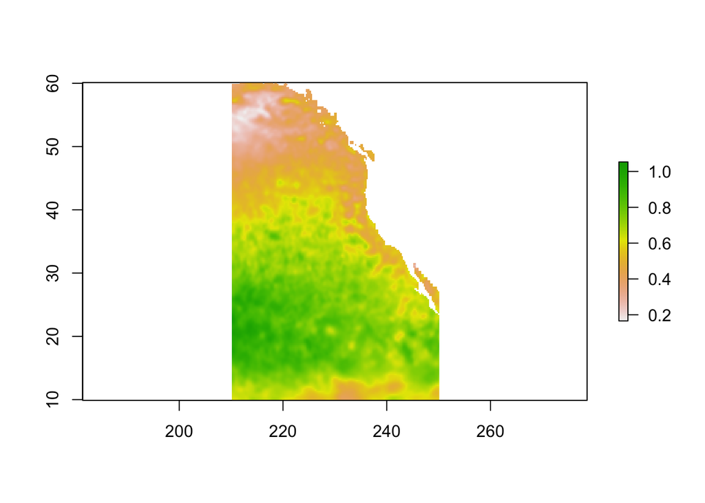

2(5.) File: aviso_delayed_time_madt_u_DATE.nc (get attributes and plot) A. Variable 1: Geostrophic velocity anomalies: zonal component (eastward water velocity)

```
## File /Volumes/SeaGate/ERD_DOM/ncdf/aviso_delayed_time_madt_u_1993-01-01.nc (NC_FORMAT_CLASSIC):
##
##      2 variables (excluding dimension variables):
##         double u[longitude,latitude,time]
##             _FillValue: -214748.3647
##             colorBarMaximum: 0.5
##             colorBarMinimum: -0.5
##             grid_mapping: crs
##             ioos_category: Sea Level
##             long_name: Geostrophic velocity anomalies: zonal component
##             standard_name: surface_eastward_geostrophic_sea_water_velocity_assuming_sea_level_for_geoid
##             units: m/s
##         double v[longitude,latitude,time]
##             _FillValue: -214748.3647
##             colorBarMaximum: 0.5
##             colorBarMinimum: -0.5
##             grid_mapping: crs
##             ioos_category: Sea Level
##             long_name: Geostrophic velocity anomalies: meridian component
##             standard_name: surface_northward_geostrophic_sea_water_velocity_assuming_sea_level_for_geoid
##             units: m/s
##
##      3 dimensions:
##         time  Size:32
##             _CoordinateAxisType: Time
##             actual_range: 725846400
##              actual_range: 728524800
##             axis: T
##             calendar: julian
##             ioos_category: Time
##             long_name: Time
##             standard_name: time
##             time_origin: 01-JAN-1970 00:00:00
##             units: seconds since 1970-01-01T00:00:00Z
##         latitude  Size:201
##             _CoordinateAxisType: Lat
##             actual_range: 10.125
##              actual_range: 60.125
##             axis: Y
##             ioos_category: Location
```

[output cut: 46 more lines]

```
##         Metadata_Conventions: CF-1.6, COARDS, Unidata Dataset Discovery v1.0
##         Northernmost_Northing: 60.125
##         platform: AltiKa, Cryosat-2, Haiyang-2A, Jason2
##         product_version: 5.6
##         project: SSALTO/DUACS
##         references: www.aviso.altimetry.fr
##         sourceUrl: (local files)
##         Southernmost_Northing: 10.125
##         standard_name_vocabulary: http://cf-pcmdi.llnl.gov/documents/cf-standard-names/standard-name-table/12/cf-standard-name-table.html
##         summary: This dataset contains Delayed Time Level-4 geostrophic velocities products from multi-satellite observations over Global Ocean.
##         time_coverage_end: 1993-02-01T00:00:00Z
##         time_coverage_resolution: P1D
##         time_coverage_start: 1993-01-01T00:00:00Z
##         title: DT merged Global Ocean Gridded Geostrophic Velocities SSALTO/Duacs L4 product
##         Westernmost_Easting: 210.125
```

```
## class       : RasterLayer
## dimensions  : 201, 161, 32361  (nrow, ncol, ncell)
## resolution  : 0.25, 0.25  (x, y)
## extent      : 209.875, 250.125, 9.875, 60.125  (xmin, xmax, ymin, ymax)
## coord. ref. : NA
## data source : in memory
## names       : layer
## values      : -0.4927, 0.5406  (min, max)
```

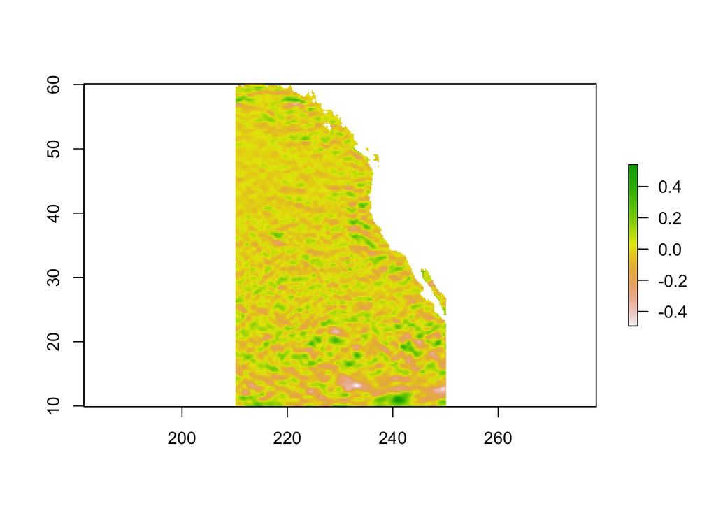

3(5.) File: aviso_delayed_time_madt_u_DATE.nc (get attributes and plot) B. Variable 1: Geostrophic velocity anomalies: meridian component (northward water velocity)

```
## File /Volumes/SeaGate/ERD_DOM/ncdf/aviso_delayed_time_madt_u_1993-01-01.nc (NC_FORMAT_CLASSIC):
##
##      2 variables (excluding dimension variables):
##         double u[longitude,latitude,time]
##             _FillValue: -214748.3647
##             colorBarMaximum: 0.5
##             colorBarMinimum: -0.5
##             grid_mapping: crs
##             ioos_category: Sea Level
##             long_name: Geostrophic velocity anomalies: zonal component
##             standard_name: surface_eastward_geostrophic_sea_water_velocity_assuming_sea_level_for_geoid
##             units: m/s
##         double v[longitude,latitude,time]
##             _FillValue: -214748.3647
##             colorBarMaximum: 0.5
##             colorBarMinimum: -0.5
##             grid_mapping: crs
##             ioos_category: Sea Level
##             long_name: Geostrophic velocity anomalies: meridian component
##             standard_name: surface_northward_geostrophic_sea_water_velocity_assuming_sea_level_for_geoid
##             units: m/s
##
##      3 dimensions:
##         time  Size:32
##             _CoordinateAxisType: Time
##             actual_range: 725846400
##              actual_range: 728524800
##             axis: T
##             calendar: julian
##             ioos_category: Time
##             long_name: Time
##             standard_name: time
##             time_origin: 01-JAN-1970 00:00:00
##             units: seconds since 1970-01-01T00:00:00Z
##         latitude  Size:201
##             _CoordinateAxisType: Lat
##             actual_range: 10.125
##              actual_range: 60.125
##             axis: Y
##             ioos_category: Location
```

[output cut: 46 more lines]

```
##         Metadata_Conventions: CF-1.6, COARDS, Unidata Dataset Discovery v1.0
##         Northernmost_Northing: 60.125
##         platform: AltiKa, Cryosat-2, Haiyang-2A, Jason2
##         product_version: 5.6
##         project: SSALTO/DUACS
##         references: www.aviso.altimetry.fr
##         sourceUrl: (local files)
##         Southernmost_Northing: 10.125
##         standard_name_vocabulary: http://cf-pcmdi.llnl.gov/documents/cf-standard-names/standard-name-table/12/cf-standard-name-table.html
##         summary: This dataset contains Delayed Time Level-4 geostrophic velocities products from multi-satellite observations over Global Ocean.
##         time_coverage_end: 1993-02-01T00:00:00Z
##         time_coverage_resolution: P1D
##         time_coverage_start: 1993-01-01T00:00:00Z
##         title: DT merged Global Ocean Gridded Geostrophic Velocities SSALTO/Duacs L4 product
##         Westernmost_Easting: 210.125
```

```
## class       : RasterLayer
## dimensions  : 201, 161, 32361  (nrow, ncol, ncell)
## resolution  : 0.25, 0.25  (x, y)
## extent      : 209.875, 250.125, 9.875, 60.125  (xmin, xmax, ymin, ymax)
## coord. ref. : NA
## data source : in memory
## names       : layer
## values      : -0.3742, 0.4242  (min, max)
```

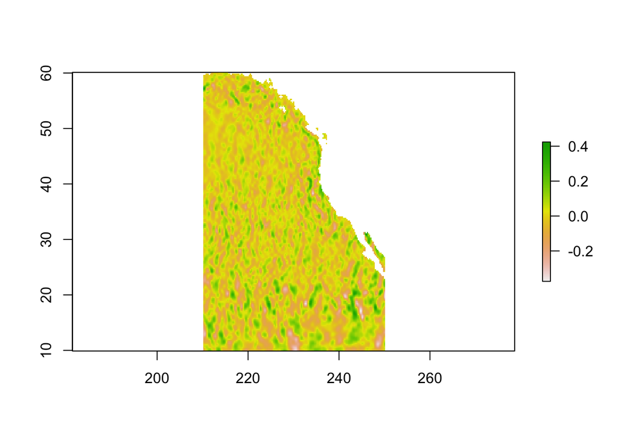

```
                                  Parent folder: /ncdf_2015/
```

4(29.) File: dt_global_allsat_madt_h_20150101_20150914.nc (get attributes and plot) Delayed-Time Level-4 sea surface height above Geoid products from multi-satellite observations.

```
## File /Volumes/SeaGate/ERD_DOM/ncdf_2015/dt_global_allsat_madt_h_20150101_20150914.nc (NC_FORMAT_CLASSIC):
##
##      4 variables (excluding dimension variables):
##         float lat_bnds[nv,lat]
##             comment: latitude values at the north and south bounds of each pixel.
##             units: degrees_north
##         float lon_bnds[nv,lon]
##             comment: longitude values at the west and east bounds of each pixel.
##             units: degrees_east
##         int crs[]
##             comment: This is a container variable that describes the grid_mapping used by the data in this file. This variable does not contain any data; only information about the geographic coordinate system.
##             grid_mapping_name: latitude_longitude
##             inverse_flattening: 298.257
##             semi_major_axis: 6378136.3
##         int adt[lon,lat,time]
##             _FillValue: -2147483647
##             coordinates: lon lat
##             grid_mapping: crs
##             long_name: Absolute Dynamic Topography
##             scale_factor: 1e-04
##             standard_name: sea_surface_height_above_geoid
##             units: m
##
##      4 dimensions:
##         time  Size:1
##             axis: T
##             calendar: gregorian
##             long_name: Time
##             standard_name: time
##             units: days since 1950-01-01 00:00:00
##         lat  Size:720
##             axis: Y
##             bounds: lat_bnds
##             long_name: Latitude
##             standard_name: latitude
##             units: degrees_north
##             valid_max: 89.875
##             valid_min: -89.875
##         lon  Size:1440
##             axis: X
```

[output cut: 39 more lines]

```
##         license: http://www.aviso.altimetry.fr/fileadmin/documents/data/License_Aviso.pdf
##         platform: AltiKa, Cryosat-2, Haiyang-2A, OSTM/Jason-2
##         processing_level: L4
##         product_version: 5.7
##         project: SSALTO/DUACS :  Data Unification and Altimeter Combination System
##         references: http://www.aviso.altimetry.fr
##         source: Altimetry measurements
##         ssalto_duacs_comment: The reference mission used for the altimeter inter-calibration processing is Topex/Poseidon between 1993-01-01 and 2002-04-23, Jason-1 between 2002-04-24 and 2008-10-18, OSTM/Jason-2 since 2008-10-19.
##         standard_name_vocabulary: NetCDF Climate and Forecast (CF) Metadata Convention Standard Name Table v28
##         summary: Delayed-Time Level-4 sea surface height above Geoid products from multi-satellite observations.
##         time_coverage_duration: P1D
##         time_coverage_end: 2015-01-01T12:00:00Z
##         time_coverage_resolution: P1D
##         time_coverage_start: 2014-12-31T12:00:00Z
##         title: DT merged all satellites Global Ocean Gridded Absolute Dynamic Topography L4 product
```

```
## class       : RasterLayer
## dimensions  : 720, 1440, 1036800  (nrow, ncol, ncell)
## resolution  : 0.25, 0.25  (x, y)
## extent      : 0, 360, -90, 90  (xmin, xmax, ymin, ymax)
## coord. ref. : +proj=longlat +rf=298.257 +a=6378136.3
## data source : /Volumes/SeaGate/ERD_DOM/ncdf_2015/dt_global_allsat_madt_h_20150101_20150914.nc
## names       : Absolute.Dynamic.Topography
## z-value     : 2015-01-01
## zvar        : adt
```

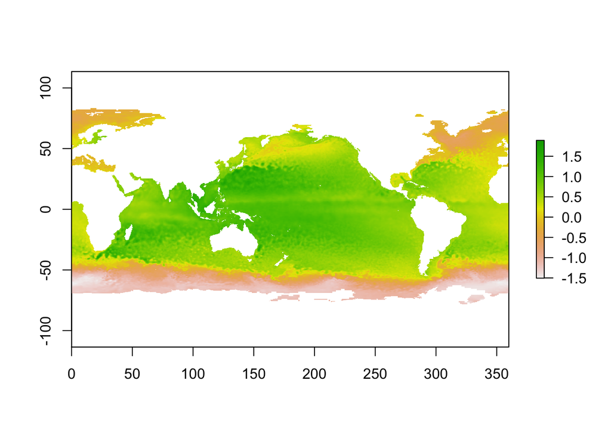

5(30.) File: dt_global_allsat_madt_uv_20150101_20150914.nc (get attributes and plot) DT merged all satellites Global Ocean Gridded Absolute Geostrophic Velocities L4 product - surface_eastward_geostrophic_sea_water_velocity

```
## File /Volumes/SeaGate/ERD_DOM/ncdf_2015/dt_global_allsat_madt_uv_20150101_20150914.nc (NC_FORMAT_CLASSIC):
##
##      5 variables (excluding dimension variables):
##         float lat_bnds[nv,lat]
##             comment: latitude values at the north and south bounds of each pixel.
##             units: degrees_north
##         float lon_bnds[nv,lon]
##             comment: longitude values at the west and east bounds of each pixel.
##             units: degrees_east
##         int crs[]
##             comment: This is a container variable that describes the grid_mapping used by the data in this file. This variable does not contain any data; only information about the geographic coordinate system.
##             grid_mapping_name: latitude_longitude
##             inverse_flattening: 298.257
##             semi_major_axis: 6378136.3
##         int u[lon,lat,time]
##             _FillValue: -2147483647
##             coordinates: lon lat
##             grid_mapping: crs
##             long_name: Absolute geostrophic velocity: zonal component
##             scale_factor: 1e-04
##             standard_name: surface_eastward_geostrophic_sea_water_velocity
##             units: m/s
##         int v[lon,lat,time]
##             _FillValue: -2147483647
##             coordinates: lon lat
##             grid_mapping: crs
##             long_name: Absolute geostrophic velocity: meridian component
##             scale_factor: 1e-04
##             standard_name: surface_northward_geostrophic_sea_water_velocity
##             units: m/s
##
##      4 dimensions:
##         time  Size:1
##             axis: T
##             calendar: gregorian
##             long_name: Time
##             standard_name: time
##             units: days since 1950-01-01 00:00:00
##         lat  Size:720
##             axis: Y
```

[output cut: 47 more lines]

```
##         license: http://www.aviso.altimetry.fr/fileadmin/documents/data/License_Aviso.pdf
##         platform: AltiKa, Cryosat-2, Haiyang-2A, OSTM/Jason-2
##         processing_level: L4p
##         product_version: 5.7
##         project: SSALTO/DUACS :  Data Unification and Altimeter Combination System
##         references: http://www.aviso.altimetry.fr
##         source: Altimetry measurements
##         ssalto_duacs_comment: The reference mission used for the altimeter inter-calibration processing is Topex/Poseidon between 1993-01-01 and 2002-04-23, Jason-1 between 2002-04-24 and 2008-10-18, OSTM/Jason-2 since 2008-10-19.
##         standard_name_vocabulary: NetCDF Climate and Forecast (CF) Metadata Convention Standard Name Table v28
##         summary: Delayed-Time Level-4 absolute geostrophic velocities products from multi-satellite observations.
##         time_coverage_duration: P1D
##         time_coverage_end: 2015-01-01T12:00:00Z
##         time_coverage_resolution: P1D
##         time_coverage_start: 2014-12-31T12:00:00Z
##         title: DT merged all satellites Global Ocean Gridded Absolute Geostrophic Velocities L4 product
```

```
## class       : RasterLayer
## dimensions  : 720, 1440, 1036800  (nrow, ncol, ncell)
## resolution  : 0.25, 0.25  (x, y)
## extent      : 0, 360, -90, 90  (xmin, xmax, ymin, ymax)
## coord. ref. : +proj=longlat +rf=298.257 +a=6378136.3
## data source : /Volumes/SeaGate/ERD_DOM/ncdf_2015/dt_global_allsat_madt_uv_20150101_20150914.nc
## names       : Absolute.geostrophic.velocity..zonal.component
## z-value     : 2015-01-01
## zvar        : u
```

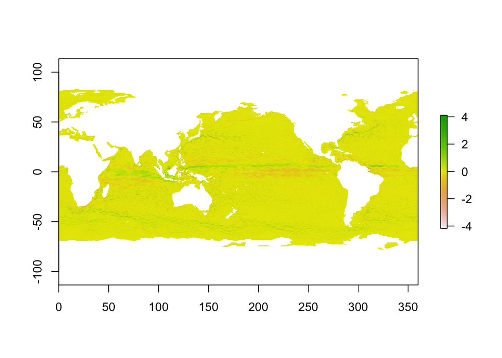

6(31.) File: dt_global_allsat_madt_uv_20150101_20150914.nc (get attributes and plot) DT merged all satellites Global Ocean Gridded Absolute Geostrophic Velocities L4 product - surface_northward_geostrophic_sea_water_velocity

```
## File /Volumes/SeaGate/ERD_DOM/ncdf_2015/dt_global_allsat_madt_uv_20150101_20150914.nc (NC_FORMAT_CLASSIC):
##
##      5 variables (excluding dimension variables):
##         float lat_bnds[nv,lat]
##             comment: latitude values at the north and south bounds of each pixel.
##             units: degrees_north
##         float lon_bnds[nv,lon]
##             comment: longitude values at the west and east bounds of each pixel.
##             units: degrees_east
##         int crs[]
##             comment: This is a container variable that describes the grid_mapping used by the data in this file. This variable does not contain any data; only information about the geographic coordinate system.
##             grid_mapping_name: latitude_longitude
##             inverse_flattening: 298.257
##             semi_major_axis: 6378136.3
##         int u[lon,lat,time]
##             _FillValue: -2147483647
##             coordinates: lon lat
##             grid_mapping: crs
##             long_name: Absolute geostrophic velocity: zonal component
##             scale_factor: 1e-04
##             standard_name: surface_eastward_geostrophic_sea_water_velocity
##             units: m/s
##         int v[lon,lat,time]
##             _FillValue: -2147483647
##             coordinates: lon lat
##             grid_mapping: crs
##             long_name: Absolute geostrophic velocity: meridian component
##             scale_factor: 1e-04
##             standard_name: surface_northward_geostrophic_sea_water_velocity
##             units: m/s
##
##      4 dimensions:
##         time  Size:1
##             axis: T
##             calendar: gregorian
##             long_name: Time
##             standard_name: time
##             units: days since 1950-01-01 00:00:00
##         lat  Size:720
##             axis: Y
```

[output cut: 47 more lines]

```
##         license: http://www.aviso.altimetry.fr/fileadmin/documents/data/License_Aviso.pdf
##         platform: AltiKa, Cryosat-2, Haiyang-2A, OSTM/Jason-2
##         processing_level: L4p
##         product_version: 5.7
##         project: SSALTO/DUACS :  Data Unification and Altimeter Combination System
##         references: http://www.aviso.altimetry.fr
##         source: Altimetry measurements
##         ssalto_duacs_comment: The reference mission used for the altimeter inter-calibration processing is Topex/Poseidon between 1993-01-01 and 2002-04-23, Jason-1 between 2002-04-24 and 2008-10-18, OSTM/Jason-2 since 2008-10-19.
##         standard_name_vocabulary: NetCDF Climate and Forecast (CF) Metadata Convention Standard Name Table v28
##         summary: Delayed-Time Level-4 absolute geostrophic velocities products from multi-satellite observations.
##         time_coverage_duration: P1D
##         time_coverage_end: 2015-01-01T12:00:00Z
##         time_coverage_resolution: P1D
##         time_coverage_start: 2014-12-31T12:00:00Z
##         title: DT merged all satellites Global Ocean Gridded Absolute Geostrophic Velocities L4 product
```

```
## class       : RasterLayer
## dimensions  : 720, 1440, 1036800  (nrow, ncol, ncell)
## resolution  : 0.25, 0.25  (x, y)
## extent      : 0, 360, -90, 90  (xmin, xmax, ymin, ymax)
## coord. ref. : +proj=longlat +rf=298.257 +a=6378136.3
## data source : /Volumes/SeaGate/ERD_DOM/ncdf_2015/dt_global_allsat_madt_uv_20150101_20150914.nc
## names       : Absolute.geostrophic.velocity..meridian.component
## z-value     : 2015-01-01
## zvar        : v
```

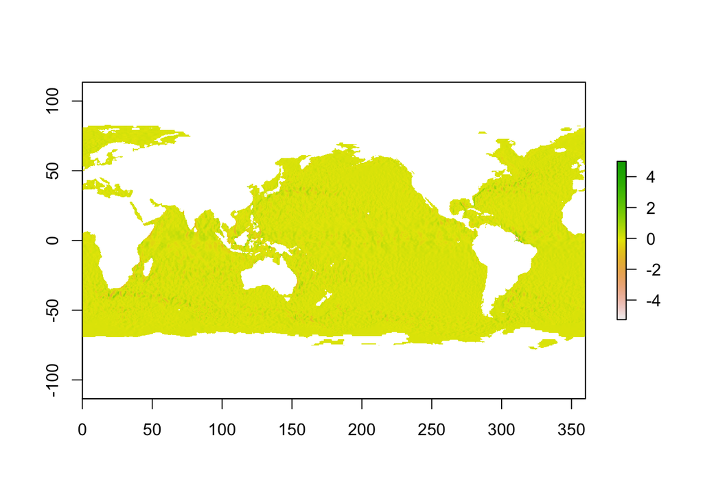

7(32.) File: dt_global_allsat_msla_h_20150101_20150914.nc (get attributes and plot) Delayed-Time Level-4 sea surface height above Mean Sea Surface products from multi-satellite observations.

```
## File /Volumes/SeaGate/ERD_DOM/ncdf_2015/dt_global_allsat_msla_h_20150101_20150914.nc (NC_FORMAT_CLASSIC):
##
##      5 variables (excluding dimension variables):
##         float lat_bnds[nv,lat]
##             comment: latitude values at the north and south bounds of each pixel.
##             units: degrees_north
##         float lon_bnds[nv,lon]
##             comment: longitude values at the west and east bounds of each pixel.
##             units: degrees_east
##         int crs[]
##             comment: This is a container variable that describes the grid_mapping used by the data in this file. This variable does not contain any data; only information about the geographic coordinate system.
##             grid_mapping_name: latitude_longitude
##             inverse_flattening: 298.257
##             semi_major_axis: 6378136.3
##         int sla[lon,lat,time]
##             _FillValue: -2147483647
##             coordinates: lon lat
##             grid_mapping: crs
##             long_name: Sea Level Anomalies
##             scale_factor: 1e-04
##             standard_name: sea_surface_height_above_sea_level
##             units: m
##         int err[lon,lat,time]
##             _FillValue: -2147483647
##             comment: The formal mapping error represents a purely theoretical mapping error. It mainly traduces errors induced by the constellation sampling capability and consistency with the spatial/temporal scales considered, as described in Le Traon et al (1998) or Ducet et al (2000)
##             coordinates: lon lat
##             grid_mapping: crs
##             long_name: Formal mapping error
##             scale_factor: 1e-04
##             units: m
##
##      4 dimensions:
##         time  Size:1
##             axis: T
##             calendar: gregorian
##             long_name: Time
##             standard_name: time
##             units: days since 1950-01-01 00:00:00
##         lat  Size:720
##             axis: Y
```

[output cut: 47 more lines]

```
##         license: http://marine.copernicus.eu/web/27-service-commitments-and-licence.php
##         platform: AltiKa, Cryosat-2, Haiyang-2A, OSTM/Jason-2
##         processing_level: L4
##         product_version: 5.7
##         project: COPERNICUS MARINE ENVIRONMENT MONITORING SERVICE (CMEMS)
##         references: http://marine.copernicus.eu
##         source: Altimetry measurements
##         ssalto_duacs_comment: The reference mission used for the altimeter inter-calibration processing is Topex/Poseidon between 1993-01-01 and 2002-04-23, Jason-1 between 2002-04-24 and 2008-10-18, OSTM/Jason-2 since 2008-10-19.
##         standard_name_vocabulary: NetCDF Climate and Forecast (CF) Metadata Convention Standard Name Table v28
##         summary: Delayed-Time Level-4 sea surface height above Mean Sea Surface products from multi-satellite observations.
##         time_coverage_duration: P1D
##         time_coverage_end: 2015-01-01T12:00:00Z
##         time_coverage_resolution: P1D
##         time_coverage_start: 2014-12-31T12:00:00Z
##         title: DT merged all satellites Global Ocean Gridded Sea Level Anomalies L4 product
```

```
## class       : RasterLayer
## dimensions  : 720, 1440, 1036800  (nrow, ncol, ncell)
## resolution  : 0.25, 0.25  (x, y)
## extent      : 0, 360, -90, 90  (xmin, xmax, ymin, ymax)
## coord. ref. : +proj=longlat +rf=298.257 +a=6378136.3
## data source : /Volumes/SeaGate/ERD_DOM/ncdf_2015/dt_global_allsat_msla_h_20150101_20150914.nc
## names       : Sea.Level.Anomalies
## z-value     : 2015-01-01
## zvar        : sla
```

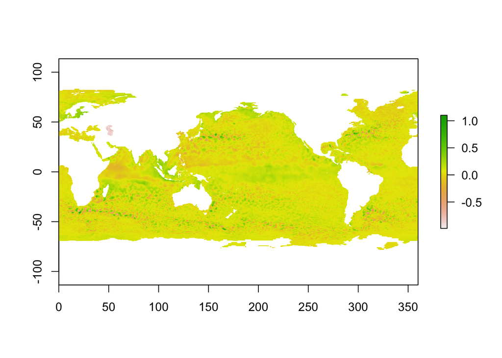

```
                                         Parent folder: /ncdf_ADD/AVISOraw
```

8() File: dt_global_allsat_msla_h_19930101_20140106.nc (get attributes and plot) DT merged Global Ocean Gridded Sea Level Anomalies SSALTO/Duacs L4 product

```
## File /Volumes/SeaGate/ERD_DOM/ncdf_ADD/AVISOraw/all-sat-DRT/h/1993/dt_global_allsat_msla_h_19930101_20140106.nc (NC_FORMAT_CLASSIC):
##
##      5 variables (excluding dimension variables):
##         float lat_bnds[nv,lat]
##         float lon_bnds[nv,lon]
##         int crs[]
##             grid_mapping_name: latitude_longitude
##             semi_major_axis: 6371000
##             inverse_flattening: 0
##         int sla[lon,lat,time]
##             _FillValue: -2147483647
##             long_name: Sea Level Anomalies
##             standard_name: sea_surface_height_above_sea_level
##             units: m
##             scale_factor: 1e-04
##         int err[lon,lat,time]
##             _FillValue: -2147483647
##             long_name: Formal mapping error
##             comment: The formal mapping error represents a purely theoretical mapping error. It mainly traduces errors induced by the constellation sampling capability and consistency with the spatial/temporal scales considered, as described in Le Traon et al (1998) or Ducet et al (2000)
##             units: m
##             scale_factor: 1e-04
##
##      4 dimensions:
##         time  Size:1
##             long_name: Time
##             standard_name: time
##             units: days since 1950-01-01 00:00:00 UTC
##             calendar: julian
##             axis: T
##         lat  Size:720
##             long_name: Latitude
##             standard_name: latitude
##             units: degrees_north
##             bounds: lat_bnds
##             axis: Y
##             valid_min: -90
##             valid_max: 90
##         lon  Size:1440
##             long_name: Longitude
##             standard_name: longitude
```

[output cut: 19 more lines]

```
##         platform: ERS-1, Topex/Poseidon
##         date_created: 2014-02-26 16:09:13
##         history: 2014-02-26 16:09:13:creation
##         Conventions: CF-1.6
##         standard_name_vocabulary: http://cf-pcmdi.llnl.gov/documents/cf-standard-names/standard-name-table/12/cf-standard-name-table.html
##         geospatial_lat_min: -90
##         geospatial_lat_max: 90
##         geospatial_lon_min: 0
##         geospatial_lon_max: 360
##         geospatial_vertical_min: 0.0
##         geospatial_vertical_max: 0.0
##         geospatial_lat_units: degrees_north
##         geospatial_lon_units: degrees_east
##         geospatial_lat_resolution: 0.25
##         geospatial_lon_resolution: 0.25
```

```
## class       : RasterLayer
## dimensions  : 720, 1440, 1036800  (nrow, ncol, ncell)
## resolution  : 0.25, 0.25  (x, y)
## extent      : 0, 360, -90, 90  (xmin, xmax, ymin, ymax)
## coord. ref. : +proj=longlat +datum=WGS84 +ellps=WGS84 +towgs84=0,0,0
## data source : /Volumes/SeaGate/ERD_DOM/ncdf_ADD/AVISOraw/all-sat-DRT/h/1993/dt_global_allsat_msla_h_19930101_20140106.nc
## names       : Sea.Level.Anomalies
## z-value     : 1993-01-01
## zvar        : sla
```

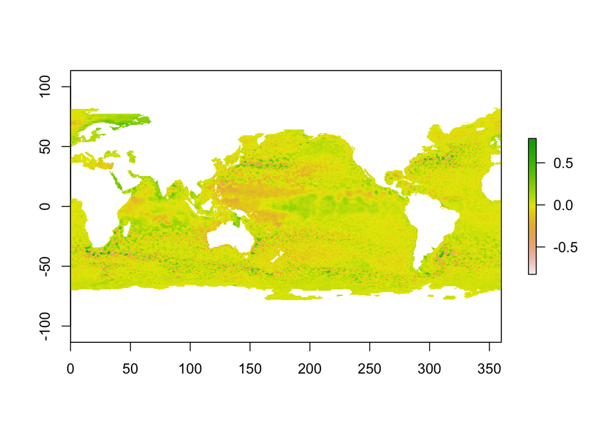